# 02: Quality Control

← Prev: Load Data Next: Unmixing & Transformation →

```r
library(flowCore)
library(flowSpecs)
library(flowWorkspace)
library(PeacoQC)
library(tidyverse)
```

```r
data(fullPanel)
fs <- flowSet(list(PBMC = fullPanel))
ff <- fs[[1]]
```

QC is performed on the raw spectral data, before unmixing. We are checking whether the instrument itself behaved consistently during acquisition — not whether the biology looks correct. The two main things to check are signal instability over time and margin events.

## Signal stability over time

Plot signal in a representative detector from each laser against acquisition time. A healthy run is flat. A sudden spike, drift, or flat section followed by a jump usually means something happened to the flow rate.

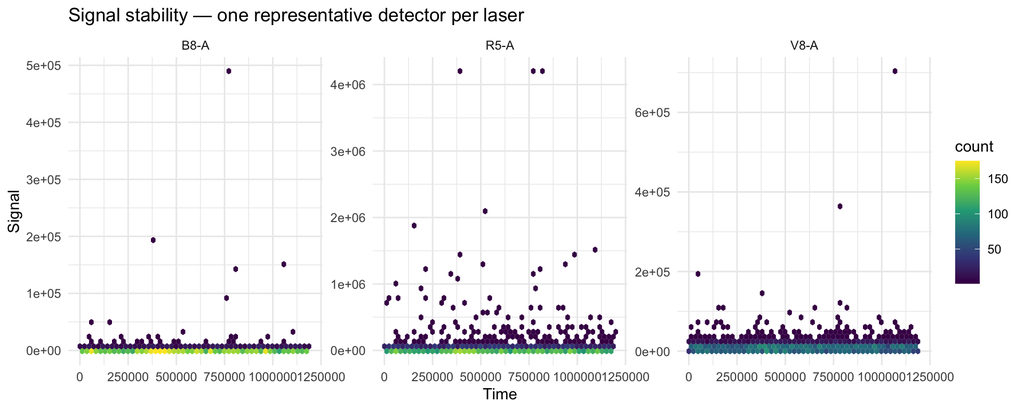

```r
df_time <- as.data.frame(exprs(ff))

df_long <- df_time[, c("Time", "V8-A", "B8-A", "R5-A")] %>%
  pivot_longer(-Time, names_to = "channel", values_to = "signal")

ggplot(df_long, aes(x = Time, y = signal)) +
  geom_hex(bins = 50) +
  scale_fill_viridis_c() +
  facet_wrap(~channel, scales = "free_y", ncol = 3) +
  theme_minimal(base_size = 11) +
  labs(title = "Signal stability — one representative detector per laser",
       x = "Time", y = "Signal")
```

> **Note:** Channel names retain their original dashes when accessed via `exprs()`. Use backtick-quoting (`` `V8-A` ``) or rename with `make.names()` if you need to reference them as data frame columns without quotes.

> **Spectral flow note:** On a 3-laser Aurora you have 42 detector channels. Pick 1–2 representative channels per laser rather than plotting all of them. If one representative channel looks clean the others on the same laser generally will too.

PeacoQC automates this detection across a subset of detectors from each laser.

```r
dir.create("output/qc", recursive = TRUE, showWarnings = FALSE)

detector_channels <- c(
  paste0("V", c(4, 8, 12), "-A"),
  paste0("B", c(4, 8, 12), "-A"),
  paste0("R", c(2, 5,  8), "-A")
)

result <- PeacoQC(
  ff               = ff,
  channels         = detector_channels,
  output_directory = "output/qc",
  name             = "PBMC",
  plot             = FALSE,
  save_fcs         = FALSE
)
ff_qc <- result$FinalFF
```

```r
cat("Events before PeacoQC:", nrow(ff), "\n")
```

```
## Events before PeacoQC: 8000
```

```r
cat("Events after PeacoQC: ", nrow(ff_qc), "\n")
```

```
## Events after PeacoQC:  6250
```

```r
cat("Retained:             ", round(100 * nrow(ff_qc) / nrow(ff), 1), "%\n")
```

```
## Retained:              78.1 %
```

Losing a small fraction is expected. Anything over 20% is worth going back to look at the time plots.

If a sample exceeds that threshold, go back to the time plots and look at *where* the instability occurred. A blip at the very start is common and less concerning — the flow rate often takes a moment to stabilise. Instability spread throughout the run is more serious.

Also check whether the remaining cell count is still adequate. Losing 25% of 100,000 events is generally fine; losing 25% of 3,000 may leave you with too few cells for reliable gating and statistics.

- **If instability was brief and cell count is adequate:** keep the sample, flag it, and note the deviation in your experiment metadata.
- **If instability was severe or cell count is insufficient:** exclude the sample and document it in your methods. If cells are still viable, reacquisition is worth considering.

The most important principle is that exclusion decisions must be made and documented before looking at your results, regardless of what you choose to do.

## Margin events

Margin events are where a detector recorded the maximum of its range — the true signal was even higher and got clipped. The actual value is unknown, so we remove them. This is distinct from what PeacoQC catches; PeacoQC looks at temporal instability, not ceiling effects.

```r
remove_margin_events <- function(ff) {
  channel_max <- parameters(ff)@data$maxRange
  names(channel_max) <- colnames(ff)
  at_ceiling <- apply(exprs(ff), 1, function(row) {
    any(row >= channel_max * 0.9999, na.rm = TRUE)
  })
  ff[!at_ceiling, ]
}

ff_clean <- remove_margin_events(ff_qc)
cat("Events after margin removal:", nrow(ff_clean), "\n")
```

```
## Events after margin removal: 6139
```

```r
cat("Total retained:             ", round(100 * nrow(ff_clean) / nrow(ff), 1), "%\n")
```

```
## Total retained:              76.7 %
```

## Save

```r
dir.create("data/processed", recursive = TRUE, showWarnings = FALSE)
saveRDS(ff_clean, "data/processed/PBMC_ff_qc.rds")
cat("QC flowFrame saved\n")
```

```
## QC flowFrame saved
```

← Prev: Load Data Next: Unmixing & Transformation →